# Assignment 1 - Data 608 Spring 2020

Abdelmalek Hajjam

2/6/2020

**Principles of Data Visualization and Introduction to ggplot2**

```r
library(tidyverse)
library(dplyr)
library(ggplot2)
library(scales)
```

I have provided you with data about the 5,000 fastest growing companies in the US, as compiled by Inc. magazine. lets read this in:

```r
inc <- read.csv("https://raw.githubusercontent.com/charleyferrari/CUNY_DATA_608/master/module1/Data/inc5000_data.csv", header= TRUE)
```

And lets preview this data:

```r
head(inc)
```

|  | Rank | Name | Growth_Rate | Revenue | Industry | Employees | City | State |
| --- | --- | --- | --- | --- | --- | --- | --- | --- |
| 1 | 1 | Fuhu | 421.48 | 1.179e+08 | Consumer Products & Services | 104 | El Segundo | CA |
| 2 | 2 | FederalConference.com | 248.31 | 4.960e+07 | Government Services | 51 | Dumfries | VA |
| 3 | 3 | The HCI Group | 245.45 | 2.550e+07 | Health | 132 | Jacksonville | FL |
| 4 | 4 | Bridger | 233.08 | 1.900e+09 | Energy | 50 | Addison | TX |
| 5 | 5 | DataXu | 213.37 | 8.700e+07 | Advertising & Marketing | 220 | Boston | MA |
| 6 | 6 | MileStone Community Builders | 179.38 | 4.570e+07 | Real Estate | 63 | Austin | TX |

```r
NA
```

```r
summary(inc)
```

```
      Rank                          Name       Growth_Rate         Revenue                                  Industry      Employees
 Min.   :   1   (Add)ventures         :   1   Min.   :  0.340   Min.   :2.000e+06   IT Services                 : 733   Min.   :    1.0
 1st Qu.:1252   @Properties           :   1   1st Qu.:  0.770   1st Qu.:5.100e+06   Business Products & Services: 482   1st Qu.:   25.0
 Median :2502   1-Stop Translation USA:   1   Median :  1.420   Median :1.090e+07   Advertising & Marketing     : 471   Median :   53.0
 Mean   :2502   110 Consulting        :   1   Mean   :  4.612   Mean   :4.822e+07   Health                      : 355   Mean   :  232.7
 3rd Qu.:3751   11thStreetCoffee.com  :   1   3rd Qu.:  3.290   3rd Qu.:2.860e+07   Software                    : 342   3rd Qu.:  132.0
 Max.   :5000   123 Exteriors         :   1   Max.   :421.480   Max.   :1.010e+10   Financial Services          : 260   Max.   :66803.0
                (Other)               :4995                                         (Other)                     :2358   NA's   :12
            City          State
 New York     : 160   CA     : 701
 Chicago      :  90   TX     : 387
 Austin       :  88   NY     : 311
 Houston      :  76   VA     : 283
 San Francisco:  75   FL     : 282
 Atlanta      :  74   IL     : 273
 (Other)      :4438   (Other):2764
```

Think a bit on what these summaries mean. Use the space below to add some more relevant non-visual exploratory information you think helps you understand this data:

```r
# overview of inc data frame
str(inc)
```

```
'data.frame':   5001 obs. of  8 variables:
 $ Rank       : int  1 2 3 4 5 6 7 8 9 10 ...
 $ Name       : Factor w/ 5001 levels "(Add)ventures",..: 1770 1633 4423 690 1198 2839 4733 1468 1869 4968 ...
 $ Growth_Rate: num  421 248 245 233 213 ...
 $ Revenue    : num  1.18e+08 4.96e+07 2.55e+07 1.90e+09 8.70e+07 ...
 $ Industry   : Factor w/ 25 levels "Advertising & Marketing",..: 5 12 13 7 1 20 10 1 5 21 ...
 $ Employees  : int  104 51 132 50 220 63 27 75 97 15 ...
 $ City       : Factor w/ 1519 levels "Acton","Addison",..: 391 365 635 2 139 66 912 1179 131 1418 ...
 $ State      : Factor w/ 52 levels "AK","AL","AR",..: 5 47 10 45 20 45 44 5 46 41 ...
```

Let’s check on some properties:

```r
colSums(is.na(inc))
```

```
       Rank        Name Growth_Rate     Revenue    Industry   Employees        City       State
          0           0           0           0           0          12           0           0
```

```r
sum(is.na(inc$Employees))
```

```
[1] 12
```

```r
sd(inc$Growth_Rate)
```

```
[1] 14.12369
```

```r
sd(inc$Revenue)
```

```
[1] 240542281
```

```r
sd(inc$Employees, na.rm = TRUE)#A few companies have missing employee counts
```

```
[1] 1353.128
```

```r
#We can also do IQR in case the data is skewed
IQR(inc$Growth_Rate)
```

```
[1] 2.52
```

```r
IQR(inc$Revenue)
```

```
[1] 23500000
```

```r
IQR(inc$Employees, na.rm = TRUE)
```

```
[1] 107
```

According to statistics class, we can create a correlation chart that can show if the variables in our data are related to one another. In this case, it does not seem that they have a simple linear relationship. There is a potential relationship between Employees and Revenue, as dipicted below in the chart produced by the following code:

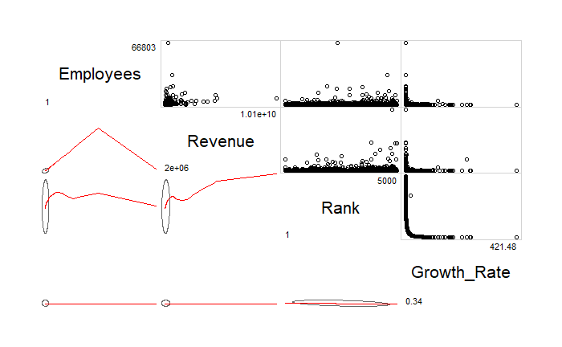

```r
library(corrgram)
corrgram(inc, order=TRUE, lower.panel=panel.ellipse,
  upper.panel=panel.pts, text.panel=panel.txt,
  diag.panel=panel.minmax)
```

## Question 1

Create a graph that shows the distribution of companies in the dataset by State (ie how many are in each state). There are a lot of States, so consider which axis you should use. This visualization is ultimately going to be consumed on a ‘portrait’ oriented screen (ie taller than wide), which should further guide your layout choices.

[figure not shown]

```r
# raw data summary
d1 <- inc %>%
    group_by(State) %>%
    tally() %>%
  rename(count = n) %>%
  arrange(desc(count))
#plot our data
g <- ggplot(d1, aes(x = reorder(State, count), y = count))
g <- g + geom_bar(stat = "identity", fill = 'darkred') + coord_flip()
g <- g + ggtitle("Distribution of 5,000 Fastest Growing Companies")
g <- g + labs(subtitle = "by state", x = "state", y = "company count")
g <- g + theme(plot.title = element_text(hjust = 0.5), plot.subtitle = element_text(hjust = 0.5))
g
# save to file
ggsave("Figure1.png", height = 9, width = 7)
```

## Quesiton 2

Lets dig in on the state with the 3rd most companies in the data set. Imagine you work for the state and are interested in how many people are employed by companies in different industries. Create a plot that shows the average and/or median employment by industry for companies in this state (only use cases with full data, use R’s `complete.cases()` function.) In addition to this, your graph should show how variable the ranges are, and you should deal with outliers.

```r
# find state with third most companies (our data is already ordered in descendant, therefore the 3rd row)
state_3 <- d1[3,"State"]
state_3
```

| State |
| --- |
| NY |

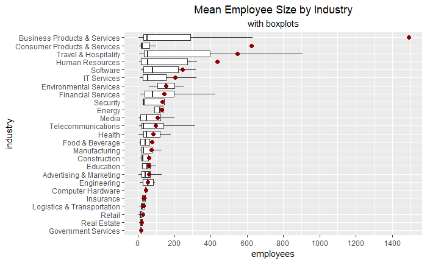

```r
# filter original data: complete cases and 3rd ranked state only
data_3 <- inc[complete.cases(inc),] %>%
  inner_join(state_3, by = "State")

# find mean employees by industry
means <- aggregate(Employees ~ Industry, data_3, mean)

# find maximum average employee no.
means_max <- max(means$Employees)

# prepare plot data: box plots (with outliers removed) to show variation; dots for mean EEs
g <- ggplot(data_3, aes(x = reorder(Industry,Employees,mean), y = Employees))
g <- g + geom_boxplot(outlier.shape = NA, show.legend=F) + coord_flip()
g <- g + labs(x = "industry", y = "employees", title="Mean Employee Size by Industry")
g <- g + labs(subtitle = "with boxplots")
g <- g + geom_point(data = means, aes(x=Industry, y=Employees), color='darkred', size = 2)
g <- g + theme(plot.title = element_text(hjust = 0.5), plot.subtitle = element_text(hjust = 0.5))

# plot data, linear scale
g <- g +  scale_y_continuous(limits = c(0,means_max), breaks = seq(0, means_max, 200))
g

# save to file
ggsave("Figure2_part1.png", height = 9, width = 7)
```

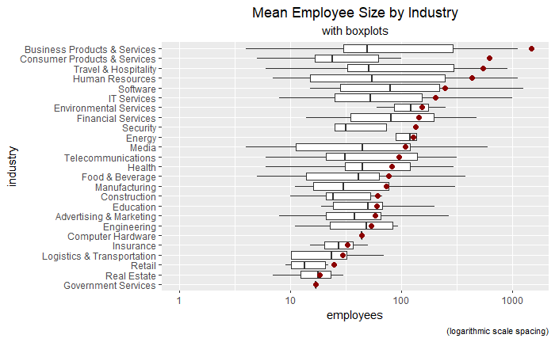

```r
# plot data, log scale
g <- g + scale_y_log10(limits = c(1, means_max))
g <- g + labs(caption = "(logarithmic scale spacing)")
g <- g + theme(plot.caption = element_text(size = 8))
g
#save to file
ggsave("Figure2_part2.png", height = 9, width = 7)
```

## Question 3

Now imagine you work for an investor and want to see which industries generate the most revenue per employee. Create a chart that makes this information clear. Once again, the distribution per industry should be shown.

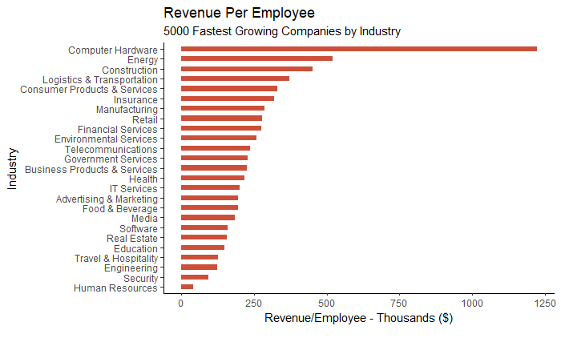

```r
d3 <- inc[complete.cases(inc$Revenue), ]
d3 <- d3[complete.cases(d3$Employees), ]
d3 <- d3 %>%
    group_by(Industry) %>%
    summarise(TotRev = sum(Revenue, na.rm=T), TotEmp = sum(Employees, na.rm=T)) %>%
    mutate(AvgRevK = (TotRev/TotEmp)/1000)

ggplot(d3, aes(x=reorder(Industry, AvgRevK), y=AvgRevK)) +
    geom_bar(stat="identity", width=.5, fill="tomato3")+
    labs(title="Revenue Per Employee",
         subtitle="5000 Fastest Growing Companies by Industry",
         caption="",
         y="Revenue/Employee - Thousands ($)",
         x="Industry") +
    theme_classic() +
    coord_flip()
ggsave('Figure3.png')
```